# Supervised Learning - Foundations Project: ReCell

### 5. Bigger screens are desirable for entertainment purposes as they offer a better viewing experience. How many phones and tablets are available across different brands with a screen size larger than 6 inches?

```python
# filter large screens only (6 inches = 15.24cm)
large_screens = data[(data['screen_size']>15.24)]
large_screens
```

|  | brand_name | os | screen_size | 4g | 5g | main_camera_mp | selfie_camera_mp | int_memory | ram | battery | weight | release_year | days_used | normalized_used_price | normalized_new_price |
| --- | --- | --- | --- | --- | --- | --- | --- | --- | --- | --- | --- | --- | --- | --- | --- |
| 1 | Honor | Android | 17.30 | yes | yes | 13.0 | 16.0 | 128.0 | 8.0 | 4300.0 | 213.0 | 2020 | 325 | 5.162097 | 5.519018 |
| 2 | Honor | Android | 16.69 | yes | yes | 13.0 | 8.0 | 128.0 | 8.0 | 4200.0 | 213.0 | 2020 | 162 | 5.111084 | 5.884631 |
| 3 | Honor | Android | 25.50 | yes | yes | 13.0 | 8.0 | 64.0 | 6.0 | 7250.0 | 480.0 | 2020 | 345 | 5.135387 | 5.630961 |
| 4 | Honor | Android | 15.32 | yes | no | 13.0 | 8.0 | 64.0 | 3.0 | 5000.0 | 185.0 | 2020 | 293 | 4.389995 | 4.947837 |
| 5 | Honor | Android | 16.23 | yes | no | 13.0 | 8.0 | 64.0 | 4.0 | 4000.0 | 176.0 | 2020 | 223 | 4.413889 | 5.060694 |
| ... | ... | ... | ... | ... | ... | ... | ... | ... | ... | ... | ... | ... | ... | ... | ... |
| 3447 | Apple | iOS | 15.27 | yes | no | 8.0 | 7.0 | 64.0 | 4.0 | 3110.0 | 194.0 | 2019 | 208 | 5.100902 | 6.287933 |
| 3448 | Asus | Android | 16.74 | yes | no | NaN | 24.0 | 128.0 | 8.0 | 6000.0 | 240.0 | 2019 | 325 | 5.715316 | 7.059317 |
| 3449 | Asus | Android | 15.34 | yes | no | NaN | 8.0 | 64.0 | 6.0 | 5000.0 | 190.0 | 2019 | 232 | 4.492337 | 6.483872 |
| 3451 | Alcatel | Android | 15.80 | yes | no | 13.0 | 5.0 | 32.0 | 3.0 | 4000.0 | 165.0 | 2020 | 201 | 4.357350 | 4.528829 |
| 3452 | Alcatel | Android | 15.80 | yes | no | 13.0 | 5.0 | 32.0 | 2.0 | 4000.0 | 160.0 | 2020 | 149 | 4.349762 | 4.624188 |

1099 rows × 15 columns

Observation: There are 1,099 devices with a screen size of over 6 inches.

```python
large_screens['brand_name'].value_counts()
```

```
Huawei       149
Samsung      119
Others        99
Vivo          80
Honor         72
Oppo          70
Xiaomi        69
Lenovo        69
LG            59
Motorola      42
Asus          41
Realme        40
Alcatel       26
Apple         24
Acer          19
ZTE           17
Meizu         17
OnePlus       16
Nokia         15
Sony          12
Infinix       10
HTC            7
Micromax       7
Google         4
Coolpad        3
Gionee         3
XOLO           3
Karbonn        2
Panasonic      2
Spice          2
Microsoft      1
Name: brand_name, dtype: int64
```

Observations:

- Huawei is the brand with the highest count of devices with a >6 inch screen with 149
- Samsung is the next highest with 119
- Microsoft has only 1

### 6. A lot of devices nowadays offer great selfie cameras, allowing us to capture our favorite moments with loved ones. What is the distribution of devices offering greater than 8MP selfie cameras across brands?

```python
# filter for >8MP selfie cameras only
great_selfie_cameras = data[(data['selfie_camera_mp']>8)]
great_selfie_cameras
```

|  | brand_name | os | screen_size | 4g | 5g | main_camera_mp | selfie_camera_mp | int_memory | ram | battery | weight | release_year | days_used | normalized_used_price | normalized_new_price |
| --- | --- | --- | --- | --- | --- | --- | --- | --- | --- | --- | --- | --- | --- | --- | --- |
| 1 | Honor | Android | 17.30 | yes | yes | 13.0 | 16.0 | 128.0 | 8.0 | 4300.0 | 213.0 | 2020 | 325 | 5.162097 | 5.519018 |
| 8 | Honor | Android | 15.32 | yes | no | 13.0 | 16.0 | 128.0 | 6.0 | 4000.0 | 165.0 | 2020 | 161 | 4.886054 | 5.299916 |
| 12 | Honor | Android | 16.69 | yes | yes | 13.0 | 16.0 | 128.0 | 8.0 | 4100.0 | 206.0 | 2019 | 537 | 5.383256 | 6.213968 |
| 13 | Honor | Android | 15.32 | yes | no | 13.0 | 16.0 | 64.0 | 4.0 | 4000.0 | 171.5 | 2019 | 336 | 4.617593 | 5.398751 |
| 16 | Honor | Android | 15.90 | yes | no | 13.0 | 32.0 | 128.0 | 6.0 | 3750.0 | 172.0 | 2019 | 395 | 5.022366 | 5.517935 |
| ... | ... | ... | ... | ... | ... | ... | ... | ... | ... | ... | ... | ... | ... | ... | ... |
| 3438 | Samsung | Android | 15.34 | yes | no | 12.0 | 16.0 | 32.0 | 3.0 | 4000.0 | 169.0 | 2019 | 369 | 4.760377 | 5.049151 |
| 3439 | Samsung | Android | 15.34 | yes | no | 12.0 | 32.0 | 64.0 | 4.0 | 4000.0 | 169.0 | 2019 | 315 | 5.137092 | 5.443240 |
| 3440 | Samsung | Android | 15.44 | yes | no | 12.0 | 10.0 | 256.0 | 12.0 | 4300.0 | 196.0 | 2019 | 489 | 5.200153 | 6.509499 |
| 3441 | Samsung | Android | 15.32 | yes | no | 12.0 | 10.0 | 256.0 | 8.0 | 3500.0 | 168.0 | 2019 | 429 | 5.205050 | 6.250940 |
| 3448 | Asus | Android | 16.74 | yes | no | NaN | 24.0 | 128.0 | 8.0 | 6000.0 | 240.0 | 2019 | 325 | 5.715316 | 7.059317 |

655 rows × 15 columns

There are 655 devices with greater than an 8MP selfie camera.

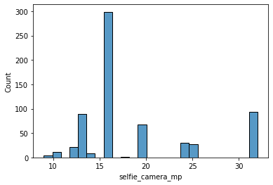

```python
# plot the distribution across devices
sns.histplot(data=great_selfie_cameras, x='selfie_camera_mp')
plt.show()
```

Observation: The amount of devices with a better than 8MP selfie camera does not follow a normal distribution.

```python
# let's see the device counts by brand name
great_selfie_cameras['brand_name'].value_counts()
```

```
Huawei        87
Vivo          78
Oppo          75
Xiaomi        63
Samsung       57
Honor         41
Others        34
LG            32
Motorola      26
Meizu         24
HTC           20
ZTE           20
Realme        18
OnePlus       18
Lenovo        14
Sony          14
Nokia         10
Asus           6
Infinix        4
Gionee         4
Coolpad        3
BlackBerry     2
Micromax       2
Panasonic      2
Acer           1
Name: brand_name, dtype: int64
```

Observations: Huawei has the most devices with great selfie cameras at 87. Acr has the least (of the brands offering devices with selfie cameras over 8MP) with just one.

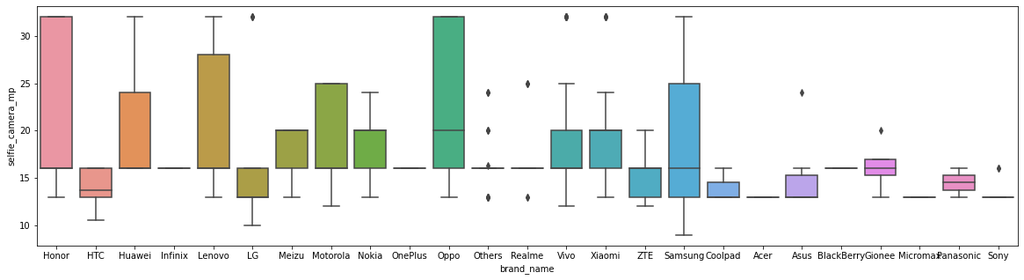

```python
# let's look at the distribution of MP by brand name
plt.figure(figsize=(20,5))
sns.boxplot(data=great_selfie_cameras, x='brand_name', y='selfie_camera_mp')
plt.show()
```

Observations: The MP offered varies by brand and within brands, but the majority of device options with a great selfie camera seem to not only be above 8MP, but above 12MP.

### 7. Which attributes are highly correlated with the normalized price of a used device?

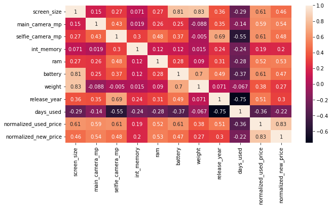

```python
# use a heatmap to see which variables are highly correlated with normalized price of a used device
plt.figure(figsize=(10,5))
sns.heatmap(data.corr(),annot=True)
plt.show()
```

Observations: the highest correlation is a positive correlation with normalized_new_price (at 0.83), which seems logical. The next highest correlation is also positive and is seen with three variables at 0.61: screen size, selfie_camera_mp, and battery.

## Data Preprocessing

- Missing value treatment
- Feature engineering (if needed)
- Outlier detection and treatment (if needed)
- Preparing data for modeling
- Any other preprocessing steps (if needed)

### Missing Value Treatment

We have 6 variables with null values. Below is each column name, the count of nulls, and the treatment I have chosen to apply.

1. main_camera_mp: 179 nulls, not normally distributed so using the median
2. selfie_camera_mp: 2 nulls, not normally distributed so using the median
3. int_memory: 4 nulls, not normally distributed so using the median
4. ram: 4 nulls, using the mode of 4 since it is by far the most common value
5. battery: 6 nulls, not normally distributed so using the median
6. weight: 7 nulls, not normally distributed so using the median

```python
# impute with the values listed above
data['main_camera_mp'] = data['main_camera_mp'].fillna(value=data['main_camera_mp'].median())
```

```python
data['selfie_camera_mp'] = data['selfie_camera_mp'].fillna(value=data['selfie_camera_mp'].median())
```

```python
data['int_memory'] = data['int_memory'].fillna(value=data['int_memory'].median())
```

```python
data['ram'] = data['ram'].fillna(value=data['ram'].mode()[0])
```

```python
data['battery'] = data['battery'].fillna(value=data['battery'].median())
```

```python
data['weight'] = data['weight'].fillna(value=data['weight'].median())
```

```python
# check to make sure we no longer have nulls
data.isnull().sum()
```

```
brand_name               0
os                       0
screen_size              0
4g                       0
5g                       0
main_camera_mp           0
selfie_camera_mp         0
int_memory               0
ram                      0
battery                  0
weight                   0
release_year             0
days_used                0
normalized_used_price    0
normalized_new_price     0
dtype: int64
```

I am going to choose not to mess with the outliers as there seem to be a lot of variables with a lot of outliers, so it seems feasible that those are the correct values for the given device.

### Feature Engineering

We have two categorical variables: brand_name and os. I am going to create 4 true/false columns for each of the OS and then drop one of the columns so there is no linear dependency between them. I think there are too many values in the brand_name column to do the same, so I will choose to drop that column altogether.

```python
# convert os to 4 columns
data = pd.get_dummies(data, columns=["os"], drop_first=False)
data.head()
```

|  | brand_name | screen_size | 4g | 5g | main_camera_mp | selfie_camera_mp | int_memory | ram | battery | weight | release_year | days_used | normalized_used_price | normalized_new_price | os_Android | os_Others | os_Windows | os_iOS |
| --- | --- | --- | --- | --- | --- | --- | --- | --- | --- | --- | --- | --- | --- | --- | --- | --- | --- | --- |
| 0 | Honor | 14.50 | yes | no | 13.0 | 5.0 | 64.0 | 3.0 | 3020.0 | 146.0 | 2020 | 127 | 4.307572 | 4.715100 | 1 | 0 | 0 | 0 |
| 1 | Honor | 17.30 | yes | yes | 13.0 | 16.0 | 128.0 | 8.0 | 4300.0 | 213.0 | 2020 | 325 | 5.162097 | 5.519018 | 1 | 0 | 0 | 0 |
| 2 | Honor | 16.69 | yes | yes | 13.0 | 8.0 | 128.0 | 8.0 | 4200.0 | 213.0 | 2020 | 162 | 5.111084 | 5.884631 | 1 | 0 | 0 | 0 |
| 3 | Honor | 25.50 | yes | yes | 13.0 | 8.0 | 64.0 | 6.0 | 7250.0 | 480.0 | 2020 | 345 | 5.135387 | 5.630961 | 1 | 0 | 0 | 0 |
| 4 | Honor | 15.32 | yes | no | 13.0 | 8.0 | 64.0 | 3.0 | 5000.0 | 185.0 | 2020 | 293 | 4.389995 | 4.947837 | 1 | 0 | 0 | 0 |

```python
# drop the 'Others' column so there is no linear dependency between the new os columns
data = data.drop(columns=['os_Others'])
data.head()
```

|  | brand_name | screen_size | 4g | 5g | main_camera_mp | selfie_camera_mp | int_memory | ram | battery | weight | release_year | days_used | normalized_used_price | normalized_new_price | os_Android | os_Windows | os_iOS |
| --- | --- | --- | --- | --- | --- | --- | --- | --- | --- | --- | --- | --- | --- | --- | --- | --- | --- |
| 0 | Honor | 14.50 | yes | no | 13.0 | 5.0 | 64.0 | 3.0 | 3020.0 | 146.0 | 2020 | 127 | 4.307572 | 4.715100 | 1 | 0 | 0 |
| 1 | Honor | 17.30 | yes | yes | 13.0 | 16.0 | 128.0 | 8.0 | 4300.0 | 213.0 | 2020 | 325 | 5.162097 | 5.519018 | 1 | 0 | 0 |
| 2 | Honor | 16.69 | yes | yes | 13.0 | 8.0 | 128.0 | 8.0 | 4200.0 | 213.0 | 2020 | 162 | 5.111084 | 5.884631 | 1 | 0 | 0 |
| 3 | Honor | 25.50 | yes | yes | 13.0 | 8.0 | 64.0 | 6.0 | 7250.0 | 480.0 | 2020 | 345 | 5.135387 | 5.630961 | 1 | 0 | 0 |
| 4 | Honor | 15.32 | yes | no | 13.0 | 8.0 | 64.0 | 3.0 | 5000.0 | 185.0 | 2020 | 293 | 4.389995 | 4.947837 | 1 | 0 | 0 |

```python
# drop the brand_name column
data.drop('brand_name',axis=1,inplace=True)
```

```python
# let's also change the 4g and 5g columns from string to boolean
data.replace({'yes': 1, 'no': 0}, inplace=True)
```

```python
# check that the 4g column changed to 0,1 values
data['4g'].unique()
```

```
array([1, 0])
```

## EDA

- It is a good idea to explore the data once again after manipulating it.

```python
# let's check to make sure we have no more nulls, our new columns were added, our brand_name column was dropped, and that our data types were changed.
data.info()
```

```
<class 'pandas.core.frame.DataFrame'>
RangeIndex: 3454 entries, 0 to 3453
Data columns (total 16 columns):
 #   Column                 Non-Null Count  Dtype
---  ------                 --------------  -----
 0   screen_size            3454 non-null   float64
 1   4g                     3454 non-null   int64
 2   5g                     3454 non-null   int64
 3   main_camera_mp         3454 non-null   float64
 4   selfie_camera_mp       3454 non-null   float64
 5   int_memory             3454 non-null   float64
 6   ram                    3454 non-null   float64
 7   battery                3454 non-null   float64
 8   weight                 3454 non-null   float64
 9   release_year           3454 non-null   int64
 10  days_used              3454 non-null   int64
 11  normalized_used_price  3454 non-null   float64
 12  normalized_new_price   3454 non-null   float64
 13  os_Android             3454 non-null   uint8
 14  os_Windows             3454 non-null   uint8
 15  os_iOS                 3454 non-null   uint8
dtypes: float64(9), int64(4), uint8(3)
memory usage: 361.0 KB
```

```python
data.describe(include='all').T
```

|  | count | mean | std | min | 25% | 50% | 75% | max |
| --- | --- | --- | --- | --- | --- | --- | --- | --- |
| screen_size | 3454.0 | 13.713115 | 3.805280 | 5.080000 | 12.700000 | 12.830000 | 15.340000 | 30.710000 |
| 4g | 3454.0 | 0.676028 | 0.468057 | 0.000000 | 0.000000 | 1.000000 | 1.000000 | 1.000000 |
| 5g | 3454.0 | 0.044007 | 0.205140 | 0.000000 | 0.000000 | 0.000000 | 0.000000 | 1.000000 |
| main_camera_mp | 3454.0 | 9.384534 | 4.700148 | 0.080000 | 5.000000 | 8.000000 | 13.000000 | 48.000000 |
| selfie_camera_mp | 3454.0 | 6.553329 | 6.968453 | 0.000000 | 2.000000 | 5.000000 | 8.000000 | 32.000000 |
| int_memory | 3454.0 | 54.546957 | 84.926611 | 0.010000 | 16.000000 | 32.000000 | 64.000000 | 1024.000000 |
| ram | 3454.0 | 4.036080 | 1.364314 | 0.020000 | 4.000000 | 4.000000 | 4.000000 | 12.000000 |
| battery | 3454.0 | 3133.170961 | 1298.565062 | 500.000000 | 2100.000000 | 3000.000000 | 4000.000000 | 9720.000000 |
| weight | 3454.0 | 182.705761 | 88.329494 | 69.000000 | 142.000000 | 160.000000 | 185.000000 | 855.000000 |
| release_year | 3454.0 | 2015.965258 | 2.298455 | 2013.000000 | 2014.000000 | 2015.500000 | 2018.000000 | 2020.000000 |
| days_used | 3454.0 | 674.869716 | 248.580166 | 91.000000 | 533.500000 | 690.500000 | 868.750000 | 1094.000000 |
| normalized_used_price | 3454.0 | 4.364712 | 0.588914 | 1.536867 | 4.033931 | 4.405133 | 4.755700 | 6.619433 |
| normalized_new_price | 3454.0 | 5.233107 | 0.683637 | 2.901422 | 4.790342 | 5.245892 | 5.673718 | 7.847841 |
| os_Android | 3454.0 | 0.930515 | 0.254313 | 0.000000 | 1.000000 | 1.000000 | 1.000000 | 1.000000 |
| os_Windows | 3454.0 | 0.019398 | 0.137939 | 0.000000 | 0.000000 | 0.000000 | 0.000000 | 1.000000 |
| os_iOS | 3454.0 | 0.010423 | 0.101573 | 0.000000 | 0.000000 | 0.000000 | 0.000000 | 1.000000 |

### Split Data into Train & Test

```python
# independent variables
X = data.drop(["normalized_used_price"], axis=1)
# dependent variable
y = data[["normalized_used_price"]]
```

```python
# let's add the intercept to data
X = sm.add_constant(X)
```

```python
# splitting into train & test with a 70:30 ratio
X_train, X_test, y_train, y_test = train_test_split(
    X, y, test_size=0.30, random_state=1
)
```

```python
print(X_train.head())
```

```
      const  screen_size  4g  5g  main_camera_mp  selfie_camera_mp  \
3026    1.0        10.29   0   0             8.0               0.3
1525    1.0        15.34   1   0            13.0               5.0
1128    1.0        12.70   0   0            13.0               5.0
3003    1.0        12.83   1   0             8.0               5.0
2907    1.0        12.88   1   0            13.0              16.0

      int_memory  ram  battery  weight  release_year  days_used  \
3026        16.0  4.0   1800.0   120.0          2014        819
1525        32.0  4.0   4050.0   225.0          2016        585
1128        32.0  4.0   2550.0   162.0          2015        727
3003        16.0  4.0   3200.0   160.0          2015        800
2907        16.0  4.0   2900.0   160.0          2017        560

      normalized_new_price  os_Android  os_Windows  os_iOS
3026              4.796204           1           0       0
1525              5.434595           1           0       0
1128              5.137914           1           0       0
3003              5.189228           1           0       0
2907              5.016220           1           0       0
```

```python
print(X_test.head())
```

```
      const  screen_size  4g  5g  main_camera_mp  selfie_camera_mp  \
866     1.0        15.24   0   0            8.00               2.0
957     1.0        10.16   0   0            3.15               0.3
280     1.0        15.39   1   0            8.00               8.0
2150    1.0        12.83   1   0           13.00              16.0
93      1.0        15.29   1   0           13.00               5.0

      int_memory   ram  battery  weight  release_year  days_used  \
866         16.0  4.00   3000.0   206.0          2014        632
957        512.0  0.25   1400.0   140.0          2013        637
280         32.0  2.00   5000.0   185.0          2020        329
2150        64.0  4.00   3200.0   148.0          2017        648
93          32.0  3.00   3500.0   179.0          2019        216

      normalized_new_price  os_Android  os_Windows  os_iOS
866               5.190788           1           0       0
957               3.884652           1           0       0
280               4.487287           1           0       0
2150              5.639422           1           0       0
93                5.300415           1           0       0
```

## Model Building - Linear Regression

```python
olsmod = sm.OLS(y_train, X_train)
olsres = olsmod.fit()
```

```python
# let's print the regression summary
print(olsres.summary())
```

```
                              OLS Regression Results
=================================================================================
Dep. Variable:     normalized_used_price   R-squared:                       0.841
Model:                               OLS   Adj. R-squared:                  0.840
Method:                    Least Squares   F-statistic:                     847.8
Date:                   Fri, 06 Jan 2023   Prob (F-statistic):               0.00
Time:                           23:47:28   Log-Likelihood:                 95.399
No. Observations:                   2417   AIC:                            -158.8
Df Residuals:                       2401   BIC:                            -66.15
Df Model:                             15
Covariance Type:               nonrobust
========================================================================================
                           coef    std err          t      P>|t|      [0.025      0.975]
----------------------------------------------------------------------------------------
const                  -53.2152      8.971     -5.932      0.000     -70.808     -35.623
screen_size              0.0251      0.003      7.551      0.000       0.019       0.032
4g                       0.0473      0.015      3.092      0.002       0.017       0.077
5g                      -0.0156      0.031     -0.500      0.617      -0.077       0.046
main_camera_mp           0.0204      0.001     14.513      0.000       0.018       0.023
selfie_camera_mp         0.0140      0.001     12.913      0.000       0.012       0.016
int_memory            9.026e-05    6.7e-05      1.347      0.178   -4.12e-05       0.000
ram                      0.0214      0.005      4.289      0.000       0.012       0.031
battery              -1.074e-05   7.09e-06     -1.515      0.130   -2.46e-05    3.16e-06
weight                   0.0009      0.000      7.021      0.000       0.001       0.001
release_year             0.0270      0.004      6.075      0.000       0.018       0.036
days_used             3.729e-05   3.06e-05      1.219      0.223   -2.27e-05    9.73e-05
normalized_new_price     0.4202      0.011     36.935      0.000       0.398       0.443
os_Android               0.0537      0.029      1.826      0.068      -0.004       0.111
os_Windows               0.0807      0.046      1.764      0.078      -0.009       0.170
os_iOS                  -0.0099      0.054     -0.184      0.854      -0.115       0.095
==============================================================================
Omnibus:                      219.770   Durbin-Watson:                   1.904
Prob(Omnibus):                  0.000   Jarque-Bera (JB):              413.839
Skew:                          -0.612   Prob(JB):                     1.37e-90
Kurtosis:                       4.616   Cond. No.                     7.47e+06
==============================================================================

Notes:
[1] Standard Errors assume that the covariance matrix of the errors is correctly specified.
[2] The condition number is large, 7.47e+06. This might indicate that there are
strong multicollinearity or other numerical problems.
```

### Interpretation of R-squared

- The R-squared tells us that our model can explain 84.1% of the variance in the training set

### Interpretation of Coefficients

- The most important variable in predicting normalized_used_price seems to be normalized_new_price. An increase of 1 normalized new price unit would result in an increase of .42 in the normalized used price.
- We saw in the heatmap that 3 variables had the same correlation coefficient with normalized_used_price at 0.61: screen size, battery, and selfie_camera_mp. As such, we would expect all 3 to have a similar effect on used price and the signs of the coefficients should be the same. However, we see that they are not as battery is negative. That means we have multicollinearity in our predictor variables.

### Interpretation of p-values

- (P > |t|) gives the p-value for each predictor variable to check the null hypothesis.
- However, we first need to ensure there is no multicollinearity before we interpret the p-values as they will change.

### Checking for Multicollinearity

We will use the Variation Inflation Factor (VIF) to see how much the variance of the estimated regression coefficient is 'inflated' by the existence of correlation among the prdictor variables in the model.

## Model Performance Check

```python
# let's check the VIF of the predictors
from statsmodels.stats.outliers_influence import variance_inflation_factor

vif_series1 = pd.Series(
    [variance_inflation_factor(X_train.values, i) for i in range(X_train.shape[1])],
    index=X_train.columns,
)
print("VIF values: \n\n{}\n".format(vif_series1))
```

```
VIF values:

const                   3.571598e+06
screen_size             7.257522e+00
4g                      2.269786e+00
5g                      1.762858e+00
main_camera_mp          1.924868e+00
selfie_camera_mp        2.572363e+00
int_memory              1.247150e+00
ram                     2.103621e+00
battery                 3.835618e+00
weight                  6.120544e+00
release_year            4.613026e+00
days_used               2.589619e+00
normalized_new_price    2.658599e+00
os_Android              2.504060e+00
os_Windows              1.623483e+00
os_iOS                  1.561528e+00
dtype: float64
```

Observations: If VIF exceeds 5, there is moderate VIF, and if it exceeds 10, it shows signs of high multicollinearity. Luckily, we have no values above 10, but we have two above 5: screen_size at 7.2 and weight at 6.1. That indicates that both of these variables are correlated with one or more independent features. We will need to drop one of them, but we want to drop the one with the least impact on our R-squared.

```python
# drop screen_size
X_train2 = X_train.drop(["screen_size"], axis=1)
olsmod_1 = sm.OLS(y_train, X_train2)
olsres_1 = olsmod_1.fit()
print(
    "R-squared:",
    np.round(olsres_1.rsquared, 3),
    "\nAdjusted R-squared:",
    np.round(olsres_1.rsquared_adj, 3),
)
```

```
R-squared: 0.837
Adjusted R-squared: 0.836
```

Observation: R-squared only decreased by 0.004 when dropping screen_size.

```python
# drop weight
X_train2 = X_train.drop(["weight"], axis=1)
olsmod_1 = sm.OLS(y_train, X_train2)
olsres_1 = olsmod_1.fit()
print(
    "R-squared:",
    np.round(olsres_1.rsquared, 3),
    "\nAdjusted R-squared:",
    np.round(olsres_1.rsquared_adj, 3),
)
```

```
R-squared: 0.838
Adjusted R-squared: 0.837
```

Observation: R-squared only decreased by 0.003 when dropping weight. Since dropping weight had a lower impact on R-squared, we will drop weight.

```python
X_train = X_train.drop(["weight"], axis=1)
```

```python
olsmod_2 = sm.OLS(y_train, X_train)
olsres_2 = olsmod_2.fit()
print(olsres_2.summary())
```

```
                              OLS Regression Results
=================================================================================
Dep. Variable:     normalized_used_price   R-squared:                       0.838
Model:                               OLS   Adj. R-squared:                  0.837
Method:                    Least Squares   F-statistic:                     887.1
Date:                   Fri, 06 Jan 2023   Prob (F-statistic):               0.00
Time:                           23:47:28   Log-Likelihood:                 70.841
No. Observations:                   2417   AIC:                            -111.7
Df Residuals:                       2402   BIC:                            -24.83
Df Model:                             14
Covariance Type:               nonrobust
========================================================================================
                           coef    std err          t      P>|t|      [0.025      0.975]
----------------------------------------------------------------------------------------
const                  -41.1835      8.894     -4.630      0.000     -58.625     -23.742
screen_size              0.0422      0.002     18.369      0.000       0.038       0.047
4g                       0.0367      0.015      2.391      0.017       0.007       0.067
5g                      -0.0127      0.032     -0.403      0.687      -0.075       0.049
main_camera_mp           0.0183      0.001     13.218      0.000       0.016       0.021
selfie_camera_mp         0.0131      0.001     12.055      0.000       0.011       0.015
int_memory            8.352e-05   6.77e-05      1.234      0.217   -4.92e-05       0.000
ram                      0.0199      0.005      3.962      0.000       0.010       0.030
battery               4.751e-06    6.8e-06      0.698      0.485   -8.59e-06    1.81e-05
release_year             0.0210      0.004      4.768      0.000       0.012       0.030
days_used              5.37e-05   3.08e-05      1.743      0.081   -6.72e-06       0.000
normalized_new_price     0.4240      0.011     36.933      0.000       0.401       0.446
os_Android              -0.0048      0.028     -0.168      0.867      -0.061       0.051
os_Windows               0.0294      0.046      0.644      0.519      -0.060       0.119
os_iOS                  -0.0406      0.054     -0.752      0.452      -0.146       0.065
==============================================================================
Omnibus:                      208.532   Durbin-Watson:                   1.907
Prob(Omnibus):                  0.000   Jarque-Bera (JB):              378.169
Skew:                          -0.598   Prob(JB):                     7.62e-83
Kurtosis:                       4.525   Cond. No.                     7.32e+06
==============================================================================

Notes:
[1] Standard Errors assume that the covariance matrix of the errors is correctly specified.
[2] The condition number is large, 7.32e+06. This might indicate that there are
strong multicollinearity or other numerical problems.
```

```python
# let's check if multicollinearity is still present
vif_series2 = pd.Series(
    [variance_inflation_factor(X_train.values, i) for i in range(X_train.shape[1])],
    index=X_train.columns,
)
print("VIF values: \n\n{}\n".format(vif_series2))
```

```
VIF values:

const                   3.441266e+06
screen_size             3.388518e+00
4g                      2.247957e+00
5g                      1.762548e+00
main_camera_mp          1.842709e+00
selfie_camera_mp        2.537169e+00
int_memory              1.246894e+00
ram                     2.100018e+00
battery                 3.463821e+00
release_year            4.442759e+00
days_used               2.574507e+00
normalized_new_price    2.652817e+00
os_Android              2.303124e+00
os_Windows              1.582029e+00
os_iOS                  1.551143e+00
dtype: float64
```

Observation: VIF is less than 5 for all variables so we can say that we do not have multicollinearity in our data. We can now remove the non-significant predictor variables since the p-values of the coefficients are now reliable. We have several variables with p-values over 0.05: 5g, int_memory, battery, days_used, and our dummy variables of os_Android, os_iOS, & os_Windows. os_Android has the highest p-value of 0.867 so we will drop that one first.

```python
X_train3 = X_train.drop(["os_Android"], axis=1)
olsmod_3 = sm.OLS(y_train, X_train3)
olsres_3 = olsmod_3.fit()
print(olsres_3.summary())
```

```
                              OLS Regression Results
=================================================================================
Dep. Variable:     normalized_used_price   R-squared:                       0.838
Model:                               OLS   Adj. R-squared:                  0.837
Method:                    Least Squares   F-statistic:                     955.7
Date:                   Fri, 06 Jan 2023   Prob (F-statistic):               0.00
Time:                           23:47:28   Log-Likelihood:                 70.827
No. Observations:                   2417   AIC:                            -113.7
Df Residuals:                       2403   BIC:                            -32.59
Df Model:                             13
Covariance Type:               nonrobust
========================================================================================
                           coef    std err          t      P>|t|      [0.025      0.975]
----------------------------------------------------------------------------------------
const                  -41.1683      8.892     -4.630      0.000     -58.605     -23.732
screen_size              0.0421      0.002     19.058      0.000       0.038       0.046
4g                       0.0367      0.015      2.388      0.017       0.007       0.067
5g                      -0.0121      0.031     -0.387      0.699      -0.074       0.049
main_camera_mp           0.0183      0.001     13.348      0.000       0.016       0.021
selfie_camera_mp         0.0131      0.001     12.072      0.000       0.011       0.015
int_memory            8.377e-05   6.77e-05      1.238      0.216   -4.89e-05       0.000
ram                      0.0197      0.005      4.042      0.000       0.010       0.029
battery               4.926e-06   6.72e-06      0.733      0.464   -8.25e-06    1.81e-05
release_year             0.0210      0.004      4.768      0.000       0.012       0.030
days_used             5.338e-05   3.07e-05      1.736      0.083   -6.91e-06       0.000
normalized_new_price     0.4239      0.011     36.996      0.000       0.401       0.446
os_Windows               0.0339      0.037      0.926      0.354      -0.038       0.106
os_iOS                  -0.0356      0.045     -0.791      0.429      -0.124       0.053
==============================================================================
Omnibus:                      208.464   Durbin-Watson:                   1.907
Prob(Omnibus):                  0.000   Jarque-Bera (JB):              379.652
Skew:                          -0.596   Prob(JB):                     3.63e-83
Kurtosis:                       4.532   Cond. No.                     7.32e+06
==============================================================================

Notes:
[1] Standard Errors assume that the covariance matrix of the errors is correctly specified.
[2] The condition number is large, 7.32e+06. This might indicate that there are
strong multicollinearity or other numerical problems.
```

Observation: Upon dropping os_Android, our R-squared remains unchanged so our model performance has not suffered. But we still have several variables with high p-values. Let's also drop the next highest value: 5g at 0.699

```python
X_train4 = X_train.drop(["os_Android","5g"], axis=1)
olsmod_4 = sm.OLS(y_train, X_train4)
olsres_4 = olsmod_4.fit()
print(olsres_4.summary())
```

```
                              OLS Regression Results
=================================================================================
Dep. Variable:     normalized_used_price   R-squared:                       0.838
Model:                               OLS   Adj. R-squared:                  0.837
Method:                    Least Squares   F-statistic:                     1036.
Date:                   Fri, 06 Jan 2023   Prob (F-statistic):               0.00
Time:                           23:47:28   Log-Likelihood:                 70.752
No. Observations:                   2417   AIC:                            -115.5
Df Residuals:                       2404   BIC:                            -40.23
Df Model:                             12
Covariance Type:               nonrobust
========================================================================================
                           coef    std err          t      P>|t|      [0.025      0.975]
----------------------------------------------------------------------------------------
const                  -40.7551      8.826     -4.618      0.000     -58.063     -23.448
screen_size              0.0422      0.002     19.151      0.000       0.038       0.046
4g                       0.0370      0.015      2.415      0.016       0.007       0.067
main_camera_mp           0.0184      0.001     13.739      0.000       0.016       0.021
selfie_camera_mp         0.0131      0.001     12.074      0.000       0.011       0.015
int_memory            8.034e-05   6.71e-05      1.198      0.231   -5.12e-05       0.000
ram                      0.0189      0.004      4.312      0.000       0.010       0.027
battery               4.911e-06   6.72e-06      0.731      0.465   -8.26e-06    1.81e-05
release_year             0.0208      0.004      4.756      0.000       0.012       0.029
days_used             5.441e-05   3.06e-05      1.777      0.076   -5.64e-06       0.000
normalized_new_price     0.4233      0.011     37.205      0.000       0.401       0.446
os_Windows               0.0341      0.037      0.931      0.352      -0.038       0.106
os_iOS                  -0.0348      0.045     -0.775      0.439      -0.123       0.053
==============================================================================
Omnibus:                      209.322   Durbin-Watson:                   1.907
Prob(Omnibus):                  0.000   Jarque-Bera (JB):              380.764
Skew:                          -0.599   Prob(JB):                     2.08e-83
Kurtosis:                       4.532   Cond. No.                     7.27e+06
==============================================================================

Notes:
[1] Standard Errors assume that the covariance matrix of the errors is correctly specified.
[2] The condition number is large, 7.27e+06. This might indicate that there are
strong multicollinearity or other numerical problems.
```

Observation: after dropping both os_Android & 5g, our R-squared still remains unchanged. Let's also drop the next highest value: battery at 0.465

```python
X_train5 = X_train.drop(["os_Android","5g","battery"], axis=1)
olsmod_5 = sm.OLS(y_train, X_train5)
olsres_5 = olsmod_5.fit()
print(olsres_5.summary())
```

```
                              OLS Regression Results
=================================================================================
Dep. Variable:     normalized_used_price   R-squared:                       0.838
Model:                               OLS   Adj. R-squared:                  0.837
Method:                    Least Squares   F-statistic:                     1130.
Date:                   Fri, 06 Jan 2023   Prob (F-statistic):               0.00
Time:                           23:47:28   Log-Likelihood:                 70.483
No. Observations:                   2417   AIC:                            -117.0
Df Residuals:                       2405   BIC:                            -47.48
Df Model:                             11
Covariance Type:               nonrobust
========================================================================================
                           coef    std err          t      P>|t|      [0.025      0.975]
----------------------------------------------------------------------------------------
const                  -41.6624      8.737     -4.768      0.000     -58.796     -24.529
screen_size              0.0433      0.002     28.745      0.000       0.040       0.046
4g                       0.0380      0.015      2.493      0.013       0.008       0.068
main_camera_mp           0.0184      0.001     13.741      0.000       0.016       0.021
selfie_camera_mp         0.0131      0.001     12.075      0.000       0.011       0.015
int_memory            7.996e-05   6.71e-05      1.193      0.233   -5.15e-05       0.000
ram                      0.0188      0.004      4.292      0.000       0.010       0.027
release_year             0.0212      0.004      4.908      0.000       0.013       0.030
days_used             5.422e-05   3.06e-05      1.771      0.077   -5.82e-06       0.000
normalized_new_price     0.4241      0.011     37.411      0.000       0.402       0.446
os_Windows               0.0324      0.037      0.886      0.376      -0.039       0.104
os_iOS                  -0.0352      0.045     -0.783      0.433      -0.123       0.053
==============================================================================
Omnibus:                      208.712   Durbin-Watson:                   1.907
Prob(Omnibus):                  0.000   Jarque-Bera (JB):              380.226
Skew:                          -0.597   Prob(JB):                     2.72e-83
Kurtosis:                       4.533   Cond. No.                     3.88e+06
==============================================================================

Notes:
[1] Standard Errors assume that the covariance matrix of the errors is correctly specified.
[2] The condition number is large, 3.88e+06. This might indicate that there are
strong multicollinearity or other numerical problems.
```

Observation: After dropping os_Android, 5g, & battery, our R-squared still remains unchanged. Let's also drop the next two highest values which are our dummy os variables.

```python
X_train6 = X_train.drop(["os_Android","5g","battery","os_Windows","os_iOS"], axis=1)
olsmod_6 = sm.OLS(y_train, X_train6)
olsres_6 = olsmod_6.fit()
print(olsres_6.summary())
```

```
                              OLS Regression Results
=================================================================================
Dep. Variable:     normalized_used_price   R-squared:                       0.838
Model:                               OLS   Adj. R-squared:                  0.837
Method:                    Least Squares   F-statistic:                     1381.
Date:                   Fri, 06 Jan 2023   Prob (F-statistic):               0.00
Time:                           23:47:28   Log-Likelihood:                 69.775
No. Observations:                   2417   AIC:                            -119.6
Df Residuals:                       2407   BIC:                            -61.65
Df Model:                              9
Covariance Type:               nonrobust
========================================================================================
                           coef    std err          t      P>|t|      [0.025      0.975]
----------------------------------------------------------------------------------------
const                  -41.1765      8.725     -4.719      0.000     -58.287     -24.066
screen_size              0.0433      0.002     28.725      0.000       0.040       0.046
4g                       0.0372      0.015      2.444      0.015       0.007       0.067
main_camera_mp           0.0185      0.001     13.875      0.000       0.016       0.021
selfie_camera_mp         0.0131      0.001     12.200      0.000       0.011       0.015
int_memory            7.899e-05    6.7e-05      1.178      0.239   -5.25e-05       0.000
ram                      0.0193      0.004      4.428      0.000       0.011       0.028
release_year             0.0210      0.004      4.860      0.000       0.013       0.029
days_used             5.407e-05   3.06e-05      1.766      0.077   -5.95e-06       0.000
normalized_new_price     0.4223      0.011     38.096      0.000       0.401       0.444
==============================================================================
Omnibus:                      209.450   Durbin-Watson:                   1.909
Prob(Omnibus):                  0.000   Jarque-Bera (JB):              381.121
Skew:                          -0.599   Prob(JB):                     1.74e-83
Kurtosis:                       4.533   Cond. No.                     3.87e+06
==============================================================================

Notes:
[1] Standard Errors assume that the covariance matrix of the errors is correctly specified.
[2] The condition number is large, 3.87e+06. This might indicate that there are
strong multicollinearity or other numerical problems.
```

Observation: After dropping os_Android, 5g, & battery, os_Windows, & os_iOS, our R-squared still remains unchanged. Let's also drop the last two variables with s p-value over 0.05.

```python
X_train7 = X_train.drop(["os_Android","5g","battery","os_Windows","os_iOS","int_memory","days_used"], axis=1)
olsmod_7 = sm.OLS(y_train, X_train7)
olsres_7 = olsmod_7.fit()
print(olsres_7.summary())
```

```
                              OLS Regression Results
=================================================================================
Dep. Variable:     normalized_used_price   R-squared:                       0.837
Model:                               OLS   Adj. R-squared:                  0.837
Method:                    Least Squares   F-statistic:                     1774.
Date:                   Fri, 06 Jan 2023   Prob (F-statistic):               0.00
Time:                           23:47:28   Log-Likelihood:                 67.613
No. Observations:                   2417   AIC:                            -119.2
Df Residuals:                       2409   BIC:                            -72.90
Df Model:                              7
Covariance Type:               nonrobust
========================================================================================
                           coef    std err          t      P>|t|      [0.025      0.975]
----------------------------------------------------------------------------------------
const                  -33.0984      6.887     -4.806      0.000     -46.603     -19.594
screen_size              0.0431      0.001     28.743      0.000       0.040       0.046
4g                       0.0384      0.015      2.558      0.011       0.009       0.068
main_camera_mp           0.0186      0.001     14.204      0.000       0.016       0.021
selfie_camera_mp         0.0132      0.001     12.468      0.000       0.011       0.015
ram                      0.0186      0.004      4.293      0.000       0.010       0.027
release_year             0.0170      0.003      4.979      0.000       0.010       0.024
normalized_new_price     0.4242      0.011     39.297      0.000       0.403       0.445
==============================================================================
Omnibus:                      209.538   Durbin-Watson:                   1.909
Prob(Omnibus):                  0.000   Jarque-Bera (JB):              390.486
Skew:                          -0.591   Prob(JB):                     1.61e-85
Kurtosis:                       4.574   Cond. No.                     2.90e+06
==============================================================================

Notes:
[1] Standard Errors assume that the covariance matrix of the errors is correctly specified.
[2] The condition number is large, 2.9e+06. This might indicate that there are
strong multicollinearity or other numerical problems.
```

Observation: Our R-squared dropped slightly by .001 which is insignificant. We have now dropped all the non-significant predictor variables.

## Checking Linear Regression Assumptions

- In order to make statistical inferences from a linear regression model, it is important to ensure that the assumptions of linear regression are satisfied.

### Test for Linearity & Independence

```python
df_pred = pd.DataFrame()

df_pred["Actual Values"] = y_train.values.flatten()  # actual values
df_pred["Fitted Values"] = olsres_7.fittedvalues.values  # predicted values
df_pred["Residuals"] = olsres_7.resid.values  # residuals

df_pred.head()
```

|  | Actual Values | Fitted Values | Residuals |
| --- | --- | --- | --- |
| 0 | 4.087488 | 3.865253 | 0.222235 |
| 1 | 4.448399 | 4.581051 | -0.132651 |
| 2 | 4.315353 | 4.286071 | 0.029282 |
| 3 | 4.282068 | 4.258824 | 0.023244 |
| 4 | 4.456438 | 4.459768 | -0.003330 |

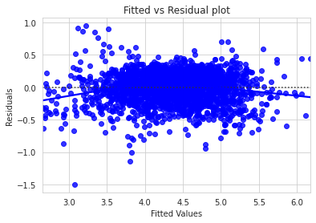

```python
# let us plot the fitted values vs residuals
sns.set_style("whitegrid")
sns.residplot(
    data=df_pred, x="Fitted Values", y="Residuals", color="blue", lowess=True
)
plt.xlabel("Fitted Values")
plt.ylabel("Residuals")
plt.title("Fitted vs Residual plot")
plt.show()
```

Observation: We can see there is a very, very slight pattern (the curved line) so our model is showing signs of non-linearity. Let's take a look at all of the continuous variables against the dependent variable to figure out which ones we need to transform.

```python
# columns in training set
X_train7.columns
```

```
Index(['const', 'screen_size', '4g', 'main_camera_mp', 'selfie_camera_mp',
       'ram', 'release_year', 'normalized_new_price'],
      dtype='object')
```

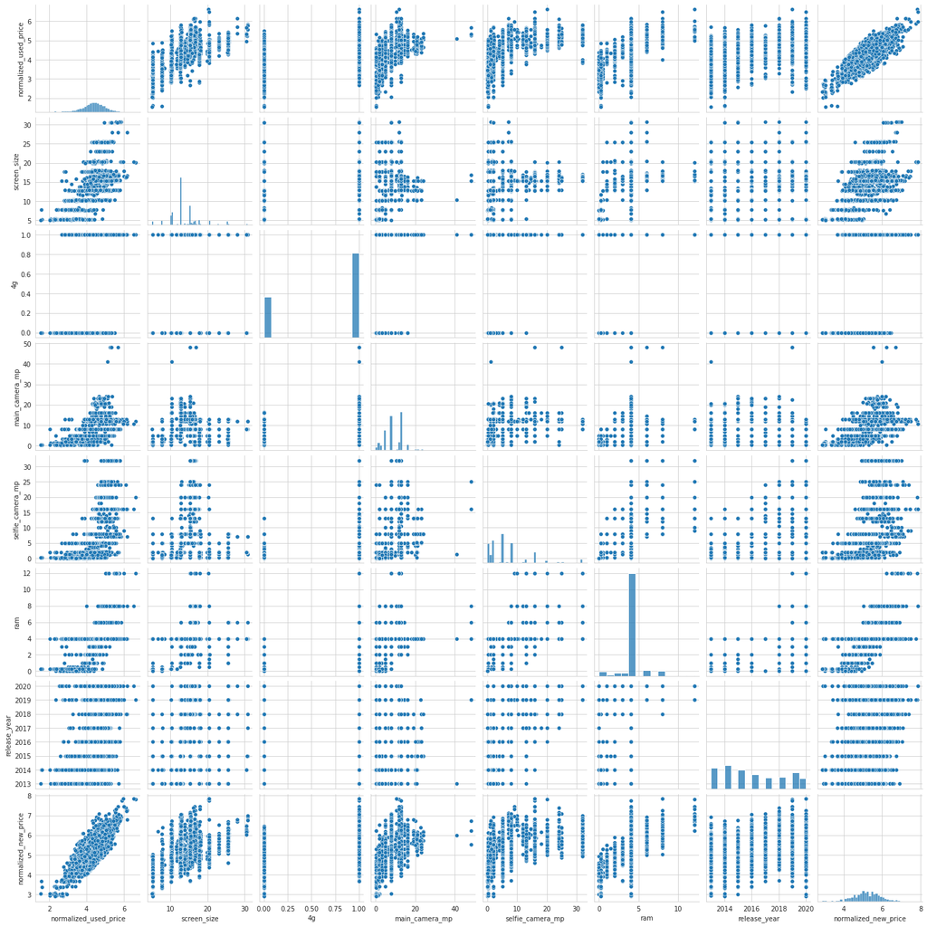

```python
# checking the distribution of variables in training set with dependent variable
sns.pairplot(data[['normalized_used_price','screen_size', '4g', 'main_camera_mp', 'selfie_camera_mp',
       'ram', 'release_year', 'normalized_new_price']])
plt.show()
```

Observation: selfie_camera_mp is the only variable with a very slight nonlinear relationship to normalized_used_price so we will transform it.

```python
# using square transformation
X_train7["selfie_camera_mp_sq"] = np.square(X_train7["selfie_camera_mp"])

# let's create a model with the transformed data
olsmod_8 = sm.OLS(y_train, X_train7)
olsres_8 = olsmod_8.fit()
print(olsres_8.summary())
```

```
                              OLS Regression Results
=================================================================================
Dep. Variable:     normalized_used_price   R-squared:                       0.838
Model:                               OLS   Adj. R-squared:                  0.838
Method:                    Least Squares   F-statistic:                     1561.
Date:                   Fri, 06 Jan 2023   Prob (F-statistic):               0.00
Time:                           23:48:00   Log-Likelihood:                 73.742
No. Observations:                   2417   AIC:                            -129.5
Df Residuals:                       2408   BIC:                            -77.37
Df Model:                              8
Covariance Type:               nonrobust
========================================================================================
                           coef    std err          t      P>|t|      [0.025      0.975]
----------------------------------------------------------------------------------------
const                  -22.0432      7.562     -2.915      0.004     -36.872      -7.214
screen_size              0.0434      0.001     28.970      0.000       0.040       0.046
4g                       0.0332      0.015      2.205      0.028       0.004       0.063
main_camera_mp           0.0170      0.001     12.293      0.000       0.014       0.020
selfie_camera_mp         0.0232      0.003      7.615      0.000       0.017       0.029
ram                      0.0199      0.004      4.583      0.000       0.011       0.028
release_year             0.0115      0.004      3.074      0.002       0.004       0.019
normalized_new_price     0.4172      0.011     38.089      0.000       0.396       0.439
selfie_camera_mp_sq     -0.0003   8.83e-05     -3.499      0.000      -0.000      -0.000
==============================================================================
Omnibus:                      198.943   Durbin-Watson:                   1.913
Prob(Omnibus):                  0.000   Jarque-Bera (JB):              367.840
Skew:                          -0.569   Prob(JB):                     1.33e-80
Kurtosis:                       4.535   Cond. No.                     3.19e+06
==============================================================================

Notes:
[1] Standard Errors assume that the covariance matrix of the errors is correctly specified.
[2] The condition number is large, 3.19e+06. This might indicate that there are
strong multicollinearity or other numerical problems.
```

Obsrvation: The R-squared increased by 0.001 back to where it was originally. Let's plot the residuals again.

```python
# let us recreate the dataframe with actual, fitted and residual values
df_pred = pd.DataFrame()

df_pred["Actual Values"] = y_train.values.flatten()  # actual values
df_pred["Fitted Values"] = olsres_8.fittedvalues.values  # predicted values
df_pred["Residuals"] = olsres_8.resid.values  # residuals

df_pred.head()
```

|  | Actual Values | Fitted Values | Residuals |
| --- | --- | --- | --- |
| 0 | 4.087488 | 3.849715 | 0.237773 |
| 1 | 4.448399 | 4.577826 | -0.129426 |
| 2 | 4.315353 | 4.294756 | 0.020597 |
| 3 | 4.282068 | 4.269952 | 0.012116 |
| 4 | 4.456438 | 4.491795 | -0.035357 |

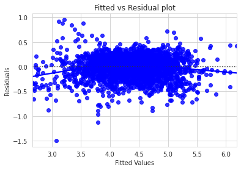

```python
# let us plot the fitted values vs residuals
sns.set_style("whitegrid")
sns.residplot(
    data=df_pred, x="Fitted Values", y="Residuals", color="blue", lowess=True
)
plt.xlabel("Fitted Values")
plt.ylabel("Residuals")
plt.title("Fitted vs Residual plot")
plt.show()
```

Observation: We observe that the pattern has slightly decreased and that the data points are seemingly randomly distributed.

### Test for Normality

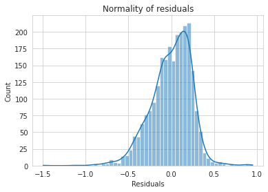

```python
sns.histplot(df_pred["Residuals"], kde=True)
plt.title("Normality of residuals")
plt.show()
```

Observation: Our residuals do not follow a perfect normal distribution, but it is close to normal. Let's check a QQ plot of residuals.

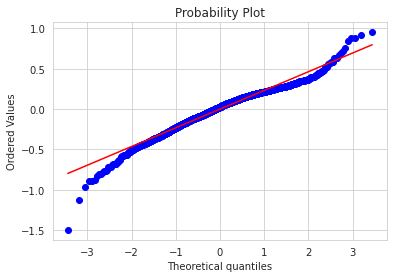

```python
import pylab
import scipy.stats as stats

stats.probplot(df_pred["Residuals"], dist="norm", plot=pylab)
plt.show()
```

Observation: The points mostly fall along the straight line, which signifies normality. Let's finally do a Shapiro-Wilk test.

```python
stats.shapiro(df_pred["Residuals"])
```

```
ShapiroResult(statistic=0.9728662967681885, pvalue=5.22342463673181e-21)
```

Observation: Since the p-value is less than 0.05, strictly speaking the residuals are not normal. However, as an approximation, we will accept this distribution as close to normal.

### Test for Homoscedasticity

```python
# import functions
import statsmodels.stats.api as sms
from statsmodels.compat import lzip

# run tgoldfeldquandt test
name = ["F statistic", "p-value"]
test = sms.het_goldfeldquandt(df_pred["Residuals"], X_train7)
lzip(name, test)
```

```
[('F statistic', 1.063208710676939), ('p-value', 0.1443254977586395)]
```

Observation: Since the p-value is > 0.05 we can say that the residuals are homoscedastic. All assumptions have now been satisfied!

## Final Model

```python
# check the summary of our final model
print(olsres_8.summary())
```

```
                              OLS Regression Results
=================================================================================
Dep. Variable:     normalized_used_price   R-squared:                       0.838
Model:                               OLS   Adj. R-squared:                  0.838
Method:                    Least Squares   F-statistic:                     1561.
Date:                   Fri, 06 Jan 2023   Prob (F-statistic):               0.00
Time:                           23:48:02   Log-Likelihood:                 73.742
No. Observations:                   2417   AIC:                            -129.5
Df Residuals:                       2408   BIC:                            -77.37
Df Model:                              8
Covariance Type:               nonrobust
========================================================================================
                           coef    std err          t      P>|t|      [0.025      0.975]
----------------------------------------------------------------------------------------
const                  -22.0432      7.562     -2.915      0.004     -36.872      -7.214
screen_size              0.0434      0.001     28.970      0.000       0.040       0.046
4g                       0.0332      0.015      2.205      0.028       0.004       0.063
main_camera_mp           0.0170      0.001     12.293      0.000       0.014       0.020
selfie_camera_mp         0.0232      0.003      7.615      0.000       0.017       0.029
ram                      0.0199      0.004      4.583      0.000       0.011       0.028
release_year             0.0115      0.004      3.074      0.002       0.004       0.019
normalized_new_price     0.4172      0.011     38.089      0.000       0.396       0.439
selfie_camera_mp_sq     -0.0003   8.83e-05     -3.499      0.000      -0.000      -0.000
==============================================================================
Omnibus:                      198.943   Durbin-Watson:                   1.913
Prob(Omnibus):                  0.000   Jarque-Bera (JB):              367.840
Skew:                          -0.569   Prob(JB):                     1.33e-80
Kurtosis:                       4.535   Cond. No.                     3.19e+06
==============================================================================

Notes:
[1] Standard Errors assume that the covariance matrix of the errors is correctly specified.
[2] The condition number is large, 3.19e+06. This might indicate that there are
strong multicollinearity or other numerical problems.
```

Observations:

R-squared of the model is 0.838 which shows the model explains about ~84% of the variance in the data.

A unit increase in the normalized_new_price will result in a 0.4172 unit increase in the normalized_used_price, all other variables remaining constant.

```python
# let's print the model parameters
olsres_8.params
```

```
const                  -22.043176
screen_size              0.043398
4g                       0.033181
main_camera_mp           0.017007
selfie_camera_mp         0.023192
ram                      0.019930
release_year             0.011530
normalized_new_price     0.417246
selfie_camera_mp_sq     -0.000309
dtype: float64
```

```python
# Let's write the equation of linear regression
Equation = "normalized_used_price ="
print(Equation, end=" ")
for i in range(len(X_train7.columns)):
    if i == 0:
        print(olsres_8.params[i], "+", end=" ")
    elif i != len(X_train7.columns) - 1:
        print(
            olsres_8.params[i],
            "* (",
            X_train7.columns[i],
            ")",
            "+",
            end="  ",
        )
    else:
        print(olsres_8.params[i], "* (", X_train7.columns[i], ")")
```

[output not shown]

### Make Predictions & Evaluate Performance

```python
X_train7.columns
```

```
Index(['const', 'screen_size', '4g', 'main_camera_mp', 'selfie_camera_mp',
       'ram', 'release_year', 'normalized_new_price', 'selfie_camera_mp_sq'],
      dtype='object')
```

```python
X_test.columns
```

```
Index(['const', 'screen_size', '4g', '5g', 'main_camera_mp',
       'selfie_camera_mp', 'int_memory', 'ram', 'battery', 'weight',
       'release_year', 'days_used', 'normalized_new_price', 'os_Android',
       'os_Windows', 'os_iOS'],
      dtype='object')
```

```python
# let's drop the columns from the test data that are not in the training data
X_test2 = X_test.drop(["5g","int_memory","battery","weight","days_used","os_Android","os_Windows","os_iOS"], axis=1)
```

```python
# let's transform the selfie_camera_mp column in the test data like the training data
X_test2["selfie_camera_mp_sq"] = np.square(X_test2["selfie_camera_mp"])
```

```python
# let's make predictions on the test set
y_pred = olsres_8.predict(X_test2)
```

```python
# let's check the RMSE on the train data
rmse1 = np.sqrt(mean_squared_error(y_train, df_pred["Fitted Values"]))
rmse1
```

```
0.23469977477130757
```

```python
# let's check the MAE on the train data
mae1 = mean_absolute_error(y_train, df_pred["Fitted Values"])
mae1
```

```
0.18441250400778966
```

```python
# let's check the MAE on the test data
mae2 = mean_absolute_error(y_test, y_pred)
mae2
```

```
0.18410383977921171
```

## Actionable Insights and Recommendations

```python
# convert to html
%%shell
jupyter nbconvert --to html //KellyDowd_SLF_Project_LearnerNotebook_FullCode.ipynb
```

```
[NbConvertApp] Converting notebook //KellyDowd_SLF_Project_LearnerNotebook_FullCode.ipynb to html
[NbConvertApp] Writing 3153412 bytes to //KellyDowd_SLF_Project_LearnerNotebook_FullCode.html
```